# Exam Scores Data Exploration

## Effects of test preparation course and parental level of education on average score

```python
# Checking for best performing students based on their parental level of education.
df.groupby('parental level of education').mean().sort_values(by='average score', ascending=False).reset_index()
```

|  | parental level of education | math score | reading score | writing score | average score |
| --- | --- | --- | --- | --- | --- |
| 0 | master's degree | 71.585714 | 75.428571 | 75.885714 | 74.304286 |
| 1 | bachelor's degree | 71.491071 | 74.008929 | 74.410714 | 73.305357 |
| 2 | associate's degree | 69.386139 | 70.841584 | 69.965347 | 70.063861 |
| 3 | some college | 65.297297 | 68.045045 | 66.734234 | 66.692342 |
| 4 | high school | 65.207921 | 67.400990 | 64.846535 | 65.817327 |
| 5 | some high school | 60.701571 | 64.408377 | 62.539267 | 62.548691 |

```python
# Creating a new column for two categories of parents: high education and low education parents.
degree_parents = []
for i in df['parental level of education'].values:
    if 'degree' in i:
        degree_parents.append('high')
    else:
        degree_parents.append('low')
df["parents' educational status"] = degree_parents

# savng the new dataset
df.to_csv('new_exam_data.csv')
```

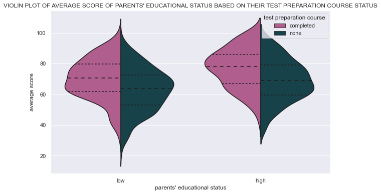

```python
multivariate_violin('average score', "parents' educational status", 'test preparation course')
```

Students of parents with low education who completed a preparation course performed better than students of parents with high education who did not undergo a test preparation course.

## Effects of lunch and parental level of education on average score

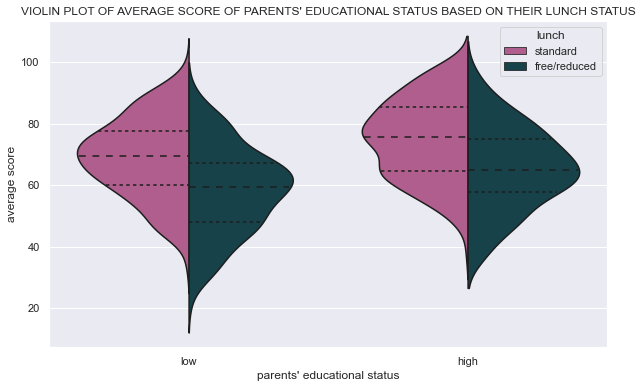

```python
multivariate_violin('average score', "parents' educational status", 'lunch')
```

Students of parents with low education who had standard lunch performed better than students of parents with high education who had free or reduced lunch.

## Talk about some of the relationships you observed in this part of the investigation. Were there features that strengthened each other in terms of looking at your feature(s) of interest?

My multivariate exploration focussed on finding out the variable with the strongest impact on students' performance since the bivariate exploration revealed that parental level of education, test preparation course, lunch and gender are the determinants of students' performance.

The analysis revealed that students of parents with low education who completed a test preparation course performed better than students of parents with high education who did not undergo a test preparation course. Also, students of parents with low education who had standard lunch performed better than students of parents with high education who had free or reduced lunch. This indicates that both test preparation course and lunch have stronger impact on students' performance than parental level of eduction.

## Were there any interesting or surprising interactions between features?

The result of the analysis showed that students who had standard lunch but did not undergo a test preparation course performed better than students who completed a test preparation course but had free or reduced lunch. This shows that lunch had a greater effect on students' performance than test preparation course.

# Conclusion

From the foregoing, it is obvious that lunch has the strongest impact on students' performance. Against all odds, students who have standard lunch perform better than students who have all other advantages except a standard lunch. In addition to lunch, test preparation course also have a strong impact on students' performance. It was observed in this analysis that students who completed a test preparation course performed better than others even when others have the advantage of high level of parental education. The feature with the weakest impact on students' performance is parent level of education. Althogh children of parents with high education performed better than those with low parental education, this feature did not weigh heavily when compared to other features.